# ALE Data exploration

#### 3.2.4.1 Blanks summary plot

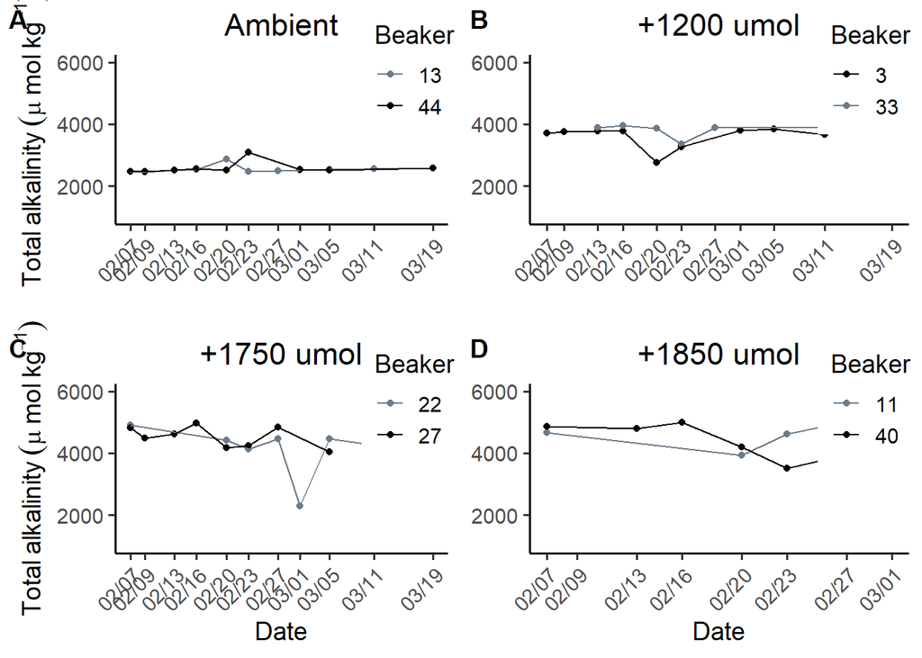

## 3.3 TotalCalcification_Alkalinity

### 3.3.1 Linear mixed effect models

#### 3.3.1.1 T0 -> T3 (before lights fixed)

to check for random effects (tank, genotype) BW from t0 to t3, growth ~ ta, 1|geno, 1|tank

```
## Linear mixed model fit by REML. t-tests use Satterthwaite's method [
## lmerModLmerTest]
## Formula: gr_t0t3 ~ avg_ta_mmol + (1 | geno) + (1 | tank)
##    Data: grdata
##
## REML criterion at convergence: -28.3
##
## Scaled residuals:
##      Min       1Q   Median       3Q      Max
## -1.63743 -0.85199  0.03426  0.80821  1.72755
##
## Random effects:
##  Groups   Name        Variance Std.Dev.
##  tank     (Intercept) 0.00749  0.08655
##  geno     (Intercept) 0.00187  0.04324
##  Residual             0.01961  0.14003
## Number of obs: 40, groups:  tank, 4; geno, 3
##
## Fixed effects:
##             Estimate Std. Error       df t value Pr(>|t|)
## (Intercept)  0.03981    0.11570 31.65611   0.344    0.733
## avg_ta_mmol  0.16477    0.02720 33.24288   6.057 7.93e-07 ***
## ---
## Signif. codes:  0 '***' 0.001 '**' 0.01 '*' 0.05 '.' 0.1 ' ' 1
##
## Correlation of Fixed Effects:
##             (Intr)
## avg_ta_mmol -0.881
```

```
## Type III Analysis of Variance Table with Satterthwaite's method
##              Sum Sq Mean Sq NumDF  DenDF F value    Pr(>F)
## avg_ta_mmol 0.71935 0.71935     1 33.243  36.687 7.928e-07 ***
## ---
## Signif. codes:  0 '***' 0.001 '**' 0.01 '*' 0.05 '.' 0.1 ' ' 1
```

```
## ANOVA-like table for random-effects: Single term deletions
##
## Model:
## gr_t0t3 ~ avg_ta_mmol + (1 | geno) + (1 | tank)
##            npar logLik     AIC    LRT Df Pr(>Chisq)
## <none>        5 14.153 -18.306
## (1 | geno)    4 13.892 -19.784 0.5220  1    0.46999
## (1 | tank)    4 11.605 -15.210 5.0958  1    0.02398 *
## ---
## Signif. codes:  0 '***' 0.001 '**' 0.01 '*' 0.05 '.' 0.1 ' ' 1
```

```
## Backward reduced random-effect table:
##
##            Eliminated npar logLik     AIC    LRT Df Pr(>Chisq)
## <none>                   5 14.153 -18.306
## (1 | geno)          1    4 13.892 -19.784 0.5220  1    0.46999
## (1 | tank)          0    3 11.522 -17.045 4.7391  1    0.02948 *
## ---
## Signif. codes:  0 '***' 0.001 '**' 0.01 '*' 0.05 '.' 0.1 ' ' 1
##
## Backward reduced fixed-effect table:
## Degrees of freedom method: Satterthwaite
##
##             Eliminated  Sum Sq Mean Sq NumDF  DenDF F value   Pr(>F)
## avg_ta_mmol          0 0.70777 0.70777     1 35.321  33.999 1.25e-06 ***
## ---
## Signif. codes:  0 '***' 0.001 '**' 0.01 '*' 0.05 '.' 0.1 ' ' 1
##
## Model found:
## gr_t0t3 ~ avg_ta_mmol + (1 | tank)
```

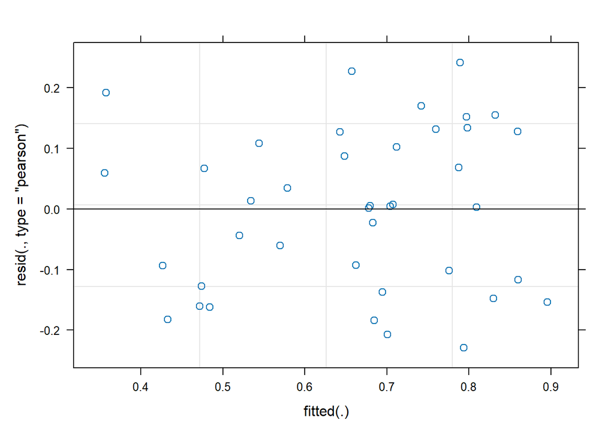

Appears there is a tank effect on bw growth when using t0 to t3 growth points… Makes sense because of my lights!

#### 3.3.1.2 T1 -> T3 (after lights fixed)

```
## Linear mixed model fit by REML. t-tests use Satterthwaite's method [
## lmerModLmerTest]
## Formula: gr_t1t3 ~ avg_ta_mmol + (1 | geno) + (1 | tank)
##    Data: grdata
##
## REML criterion at convergence: -15.5
##
## Scaled residuals:
##      Min       1Q   Median       3Q      Max
## -1.56664 -0.87670  0.07318  0.71120  2.13137
##
## Random effects:
##  Groups   Name        Variance Std.Dev.
##  tank     (Intercept) 0.001684 0.04103
##  geno     (Intercept) 0.004081 0.06388
##  Residual             0.029648 0.17219
## Number of obs: 40, groups:  tank, 4; geno, 3
##
## Fixed effects:
##             Estimate Std. Error       df t value Pr(>|t|)
## (Intercept) -0.07317    0.13466 33.84546  -0.543     0.59
## avg_ta_mmol  0.19513    0.03331 33.87748   5.859 1.33e-06 ***
## ---
## Signif. codes:  0 '***' 0.001 '**' 0.01 '*' 0.05 '.' 0.1 ' ' 1
##
## Correlation of Fixed Effects:
##             (Intr)
## avg_ta_mmol -0.927
```

```
## Type III Analysis of Variance Table with Satterthwaite's method
##             Sum Sq Mean Sq NumDF  DenDF F value   Pr(>F)
## avg_ta_mmol 1.0177  1.0177     1 33.877  34.326 1.33e-06 ***
## ---
## Signif. codes:  0 '***' 0.001 '**' 0.01 '*' 0.05 '.' 0.1 ' ' 1
```

```
## ANOVA-like table for random-effects: Single term deletions
##
## Model:
## gr_t1t3 ~ avg_ta_mmol + (1 | geno) + (1 | tank)
##            npar logLik     AIC     LRT Df Pr(>Chisq)
## <none>        5 7.7568 -5.5137
## (1 | geno)    4 7.2228 -6.4455 1.06815  1     0.3014
## (1 | tank)    4 7.6058 -7.2116 0.30209  1     0.5826
```

```
## Backward reduced random-effect table:
##
##            Eliminated npar logLik     AIC     LRT Df Pr(>Chisq)
## <none>                   5 7.7568 -5.5137
## (1 | tank)          1    4 7.6058 -7.2116 0.30209  1     0.5826
## (1 | geno)          2    3 7.1190 -8.2379 0.97367  1     0.3238
##
## Backward reduced fixed-effect table:
##             Eliminated Df Sum of Sq    RSS     AIC F value    Pr(>F)
## avg_ta_mmol          0  1    1.0005 2.2732 -112.71  29.874 3.076e-06 ***
## ---
## Signif. codes:  0 '***' 0.001 '**' 0.01 '*' 0.05 '.' 0.1 ' ' 1
##
## Model found:
## gr_t1t3 ~ avg_ta_mmol
```

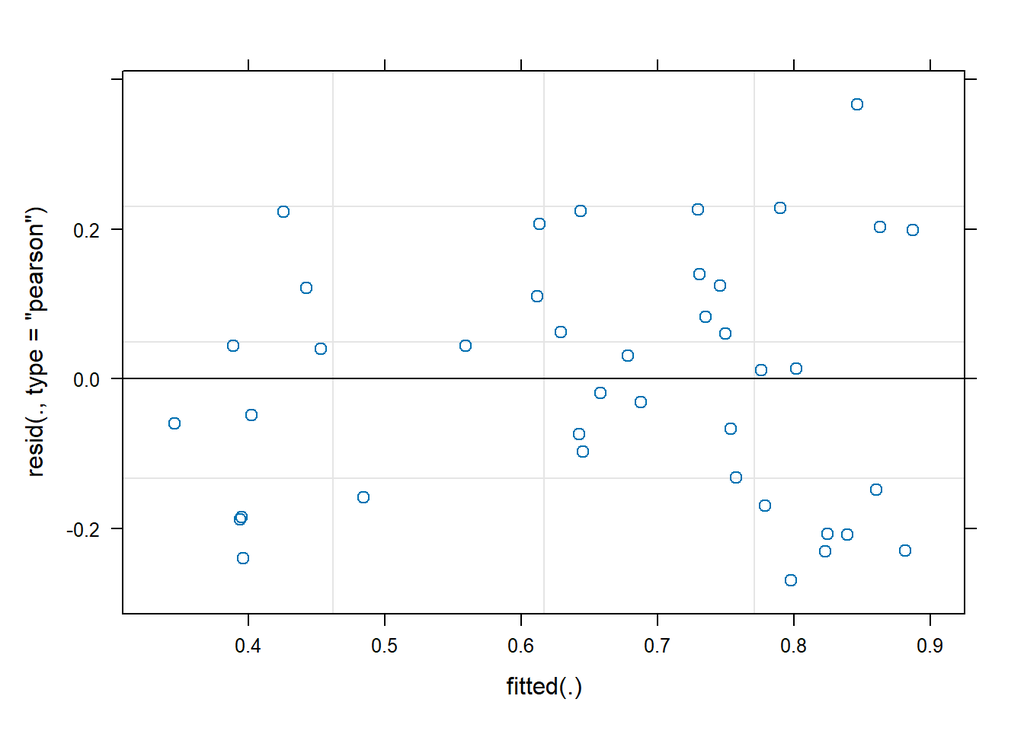

Using the timepoint after the lights were fixed eliminates the tank effect.

Simplest linear model:

```
##
## Call:
## lm(formula = gr_t1t3 ~ avg_ta_mmol, data = grdata)
##
## Residuals:
##      Min       1Q   Median       3Q      Max
## -0.30260 -0.15772 -0.00194  0.13802  0.44495
##
## Coefficients:
##             Estimate Std. Error t value Pr(>|t|)
## (Intercept) -0.05563    0.13440  -0.414    0.681
## avg_ta_mmol  0.19209    0.03514   5.466 3.08e-06 ***
## ---
## Signif. codes:  0 '***' 0.001 '**' 0.01 '*' 0.05 '.' 0.1 ' ' 1
##
## Residual standard error: 0.183 on 38 degrees of freedom
## Multiple R-squared:  0.4401, Adjusted R-squared:  0.4254
## F-statistic: 29.87 on 1 and 38 DF,  p-value: 3.076e-06
```

```
## Analysis of Variance Table
##
## Response: gr_t1t3
##             Df Sum Sq Mean Sq F value    Pr(>F)
## avg_ta_mmol  1 1.0005 1.00051  29.874 3.076e-06 ***
## Residuals   38 1.2727 0.03349
## ---
## Signif. codes:  0 '***' 0.001 '**' 0.01 '*' 0.05 '.' 0.1 ' ' 1
```

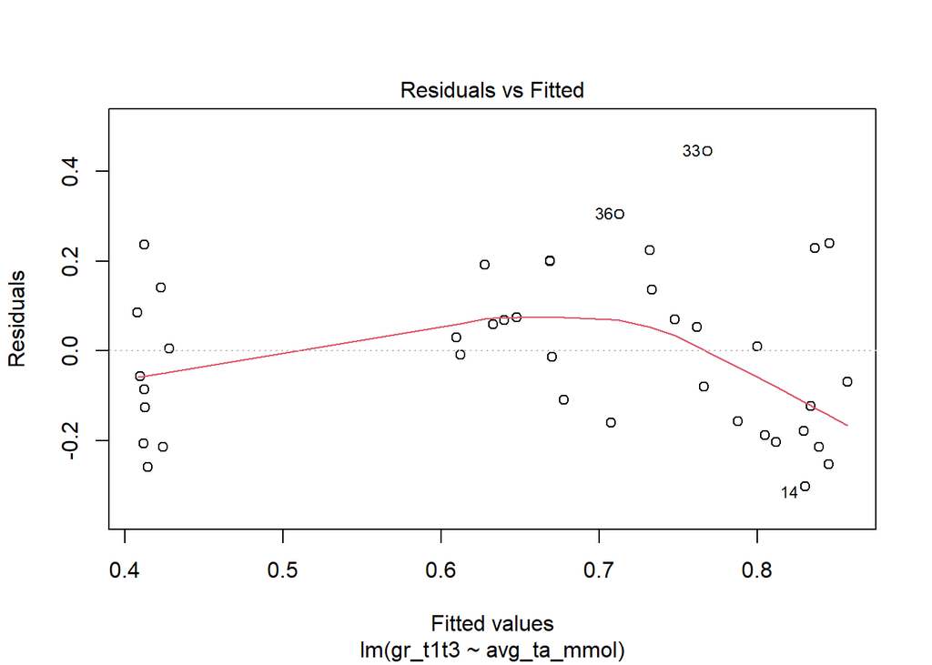

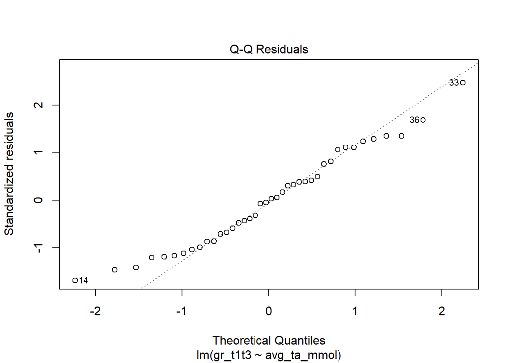

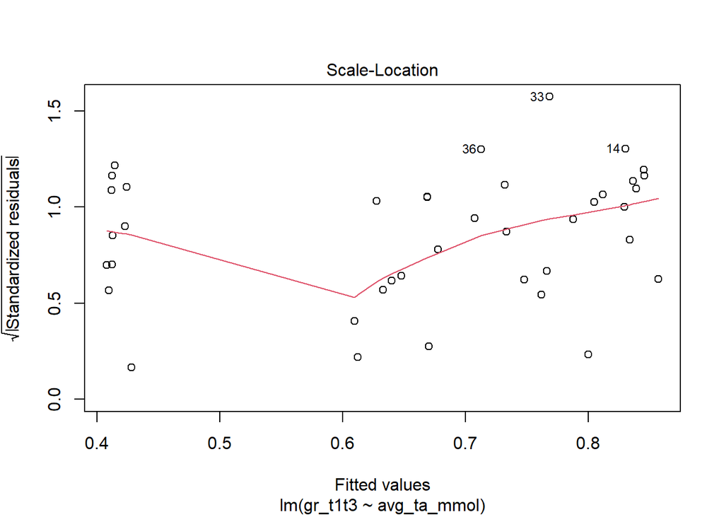

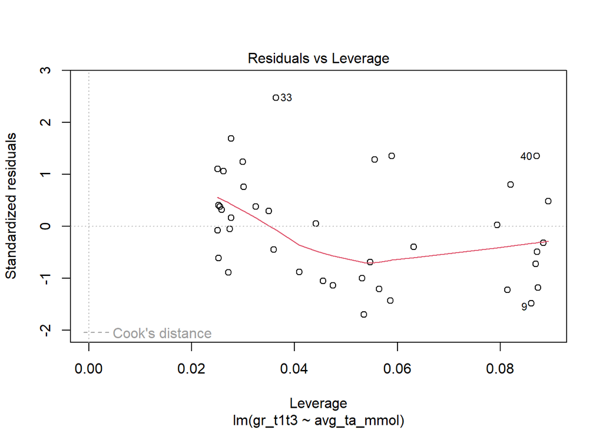

```
## [1] 0.4401405
```

```
## avg_ta_mmol
##   0.1920901
```

```
## [1] 3.076093e-06
```

```
## (Intercept)
## -0.05562571
```

### 3.3.2 Plots

#### 3.3.2.1 TA_total calcification (Linear regression, T0-T3)

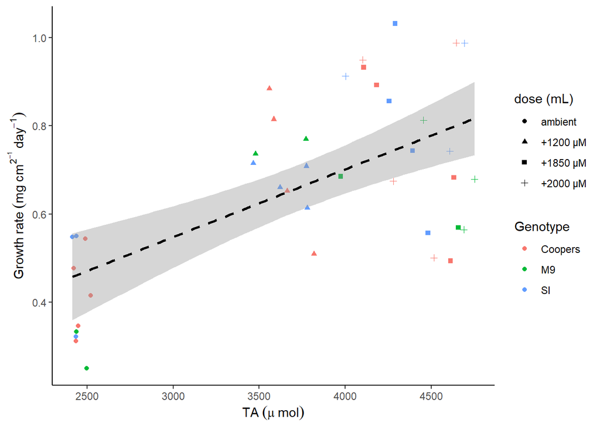

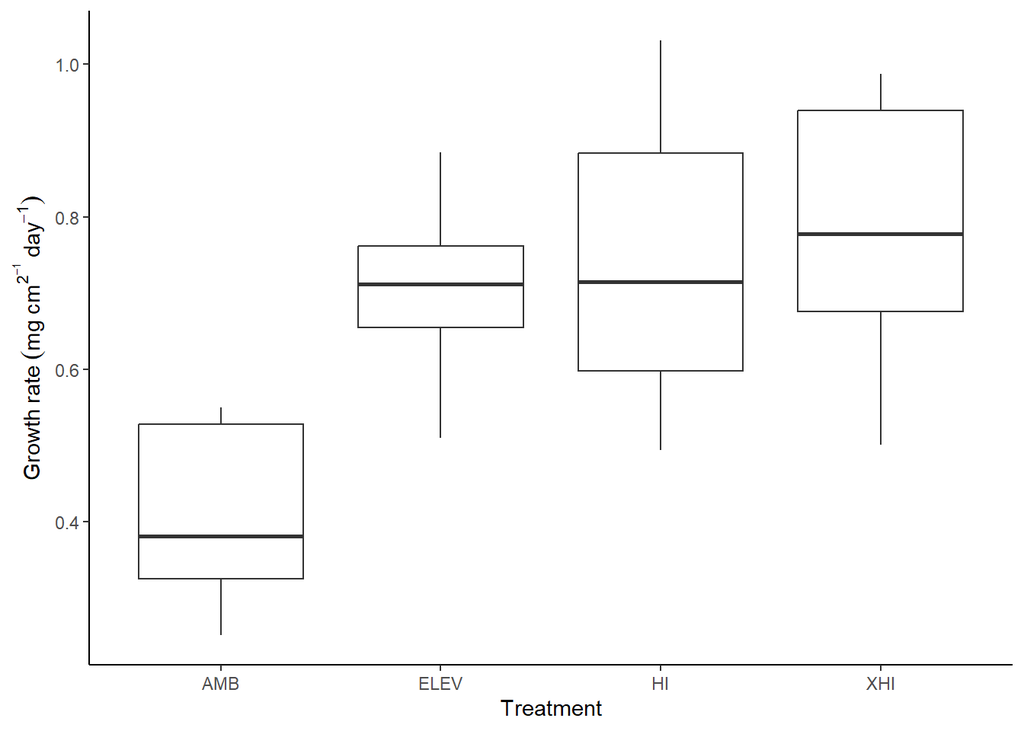

total calcification growth rates by treatment from t0 to t3

#### 3.3.2.2 TA_total calcification (Linear regression, T1-T3)

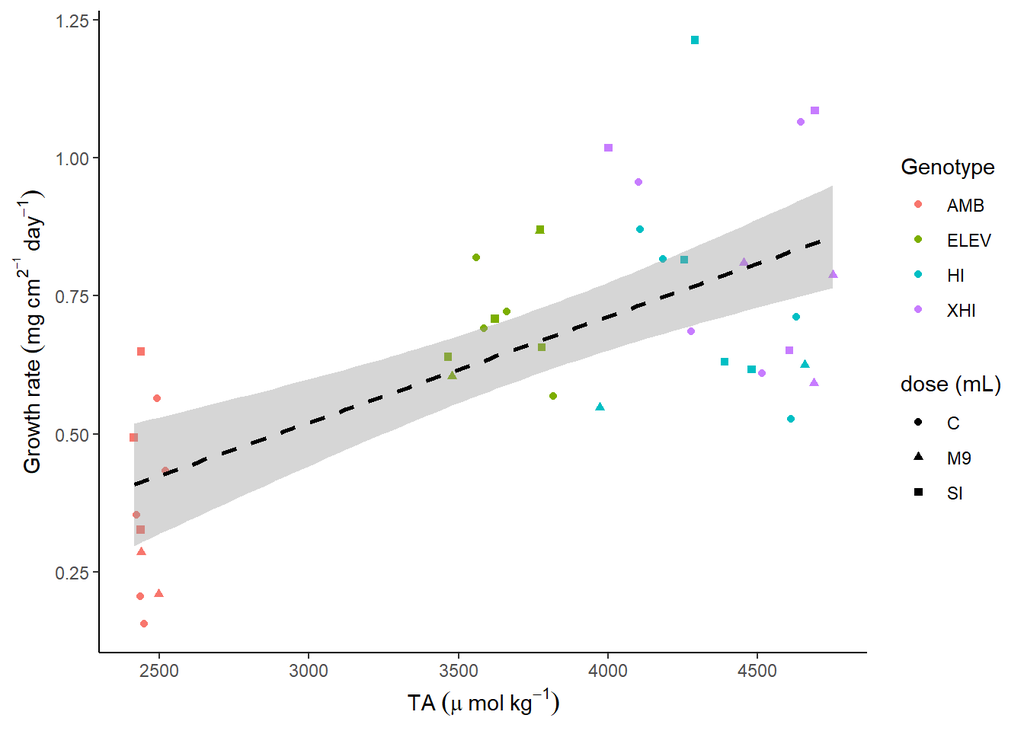

Effect of total alkalinity on calcification (standardized to initial surface area) from Feb 19th to Mar 23rd. p < 0.000

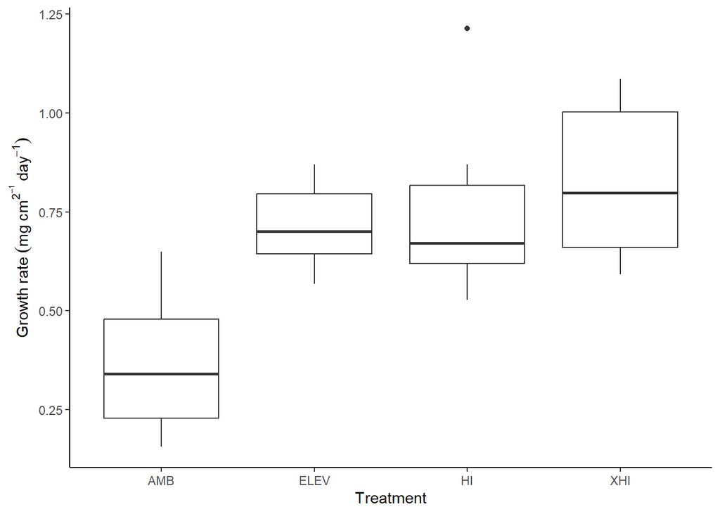

total calcification growth rates by treatment from t1 to t3

## 3.4 LinearExtension_Alkalinity

### 3.4.1 Linear mixed effect models

#### 3.4.1.1 T0 -> T3

Mixed effect model to check for genotype and tank effects on linear extension (used linear extension growth rates with the offsets)

```
## Linear mixed model fit by REML. t-tests use Satterthwaite's method [
## lmerModLmerTest]
## Formula: le_t0t3e ~ avg_ta_mmol + (1 | geno) + (1 | tank)
##    Data: grdata
##
## REML criterion at convergence: -141.2
##
## Scaled residuals:
##      Min       1Q   Median       3Q      Max
## -2.24901 -0.49283  0.07912  0.50956  2.24037
##
## Random effects:
##  Groups   Name        Variance  Std.Dev.
##  tank     (Intercept) 0.000e+00 0.000000
##  geno     (Intercept) 4.077e-05 0.006385
##  Residual             1.163e-03 0.034109
## Number of obs: 40, groups:  tank, 4; geno, 3
##
## Fixed effects:
##              Estimate Std. Error        df t value Pr(>|t|)
## (Intercept)  0.053216   0.025407 37.423382   2.095    0.043 *
## avg_ta_mmol  0.010017   0.006561 36.784991   1.527    0.135
## ---
## Signif. codes:  0 '***' 0.001 '**' 0.01 '*' 0.05 '.' 0.1 ' ' 1
##
## Correlation of Fixed Effects:
##             (Intr)
## avg_ta_mmol -0.966
## optimizer (nloptwrap) convergence code: 0 (OK)
## boundary (singular) fit: see help('isSingular')
```

```
## Type III Analysis of Variance Table with Satterthwaite's method
##                Sum Sq   Mean Sq NumDF  DenDF F value Pr(>F)
## avg_ta_mmol 0.0027121 0.0027121     1 36.785  2.3311 0.1354
```

```
## ANOVA-like table for random-effects: Single term deletions
##
## Model:
## le_t0t3e ~ avg_ta_mmol + (1 | geno) + (1 | tank)
##            npar logLik     AIC     LRT Df Pr(>Chisq)
## <none>        5 70.587 -131.17
## (1 | geno)    4 70.489 -132.98 0.19627  1     0.6577
## (1 | tank)    4 70.587 -133.17 0.00000  1     1.0000
```

```
## Backward reduced random-effect table:
##
##            Eliminated npar logLik     AIC     LRT Df Pr(>Chisq)
## <none>                   5 70.587 -131.17
## (1 | tank)          1    4 70.587 -133.17 0.00000  1     1.0000
## (1 | geno)          2    3 70.489 -134.98 0.19627  1     0.6577
##
## Backward reduced fixed-effect table:
##             Eliminated Df Sum of Sq      RSS     AIC F value Pr(>F)
## avg_ta_mmol          1  1 0.0025764 0.047891 -267.11  2.1605 0.1498
##
## Model found:
## le_t0t3e ~ 1
```

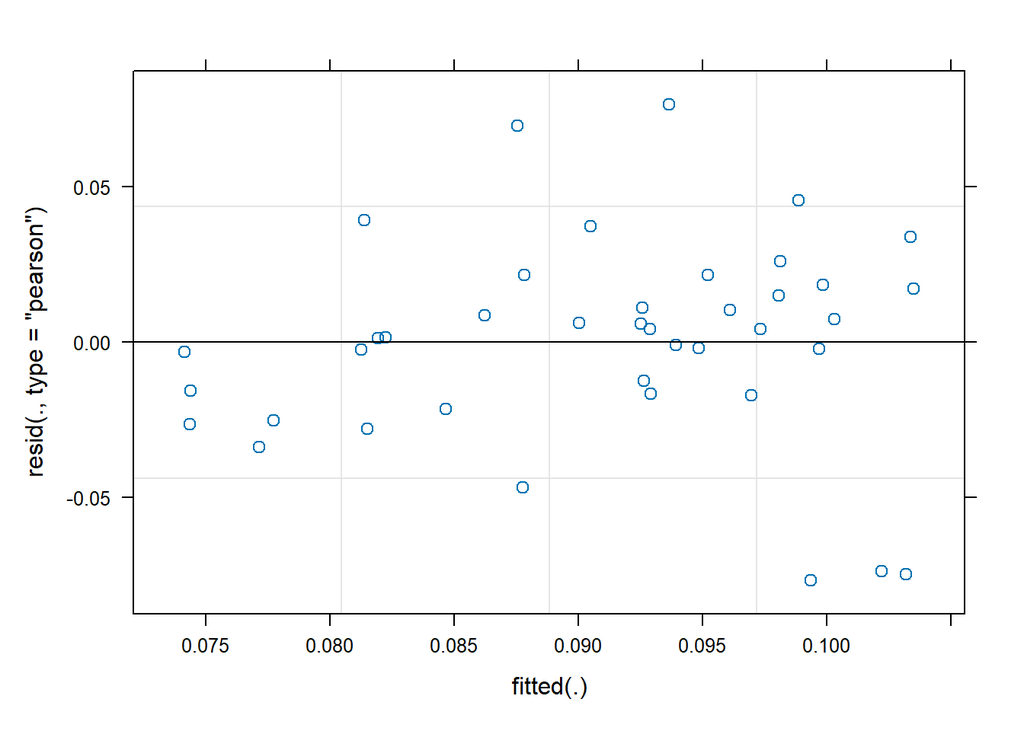

no tank of genotype effect, but also no significant effect of TA on linear extension.

#### 3.4.1.2 T1 -> T3 ’

```
## Linear mixed model fit by REML. t-tests use Satterthwaite's method [
## lmerModLmerTest]
## Formula: le_t1t3e ~ avg_ta_mmol + (1 | geno) + (1 | tank)
##    Data: grdata
##
## REML criterion at convergence: -139.7
##
## Scaled residuals:
##      Min       1Q   Median       3Q      Max
## -2.56229 -0.51364 -0.00757  0.60960  2.05723
##
## Random effects:
##  Groups   Name        Variance  Std.Dev.
##  tank     (Intercept) 0.000e+00 0.000000
##  geno     (Intercept) 5.312e-05 0.007289
##  Residual             1.204e-03 0.034696
## Number of obs: 40, groups:  tank, 4; geno, 3
##
## Fixed effects:
##              Estimate Std. Error        df t value Pr(>|t|)
## (Intercept)  0.005386   0.025929 37.230401   0.208   0.8366
## avg_ta_mmol  0.013756   0.006675 36.687488   2.061   0.0465 *
## ---
## Signif. codes:  0 '***' 0.001 '**' 0.01 '*' 0.05 '.' 0.1 ' ' 1
##
## Correlation of Fixed Effects:
##             (Intr)
## avg_ta_mmol -0.963
## optimizer (nloptwrap) convergence code: 0 (OK)
## boundary (singular) fit: see help('isSingular')
```

```
## Type III Analysis of Variance Table with Satterthwaite's method
##                Sum Sq   Mean Sq NumDF  DenDF F value  Pr(>F)
## avg_ta_mmol 0.0051128 0.0051128     1 36.687  4.2472 0.04646 *
## ---
## Signif. codes:  0 '***' 0.001 '**' 0.01 '*' 0.05 '.' 0.1 ' ' 1
```

```
## ANOVA-like table for random-effects: Single term deletions
##
## Model:
## le_t1t3e ~ avg_ta_mmol + (1 | geno) + (1 | tank)
##            npar logLik     AIC     LRT Df Pr(>Chisq)
## <none>        5 69.862 -129.72
## (1 | geno)    4 69.724 -131.45 0.27675  1     0.5988
## (1 | tank)    4 69.862 -131.72 0.00000  1     1.0000
```

```
## Backward reduced random-effect table:
##
##            Eliminated npar logLik     AIC     LRT Df Pr(>Chisq)
## <none>                   5 69.862 -129.72
## (1 | tank)          1    4 69.862 -131.72 0.00000  1     1.0000
## (1 | geno)          2    3 69.724 -133.45 0.27675  1     0.5988
##
## Backward reduced fixed-effect table:
##             Eliminated Df Sum of Sq      RSS     AIC F value  Pr(>F)
## avg_ta_mmol          1  1 0.0049664 0.052141 -263.71  4.0005 0.05267 .
## ---
## Signif. codes:  0 '***' 0.001 '**' 0.01 '*' 0.05 '.' 0.1 ' ' 1
##
## Model found:
## le_t1t3e ~ 1
```

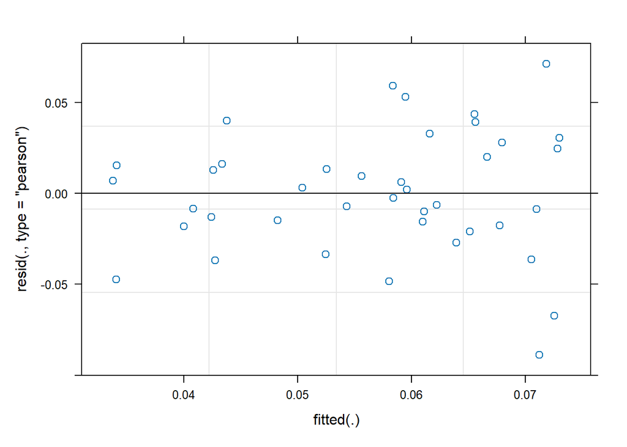

Hooray! Signficiant effect of TA on linear extension with no tank or genotype effects !!!!

```
##
## Call:
## lm(formula = le_t1t3e ~ avg_ta_mmol, data = grdata)
##
## Residuals:
##       Min        1Q    Median        3Q       Max
## -0.085147 -0.019997 -0.002287  0.024855  0.072541
##
## Coefficients:
##             Estimate Std. Error t value Pr(>|t|)
## (Intercept) 0.006363   0.025876   0.246   0.8071
## avg_ta_mmol 0.013534   0.006766   2.000   0.0527 .
## ---
## Signif. codes:  0 '***' 0.001 '**' 0.01 '*' 0.05 '.' 0.1 ' ' 1
##
## Residual standard error: 0.03523 on 38 degrees of freedom
## Multiple R-squared:  0.09525,    Adjusted R-squared:  0.07144
## F-statistic:     4 on 1 and 38 DF,  p-value: 0.05267
```

```
## Analysis of Variance Table
##
## Response: le_t1t3e
##             Df   Sum Sq   Mean Sq F value  Pr(>F)
## avg_ta_mmol  1 0.004966 0.0049664  4.0005 0.05267 .
## Residuals   38 0.047175 0.0012414
## ---
## Signif. codes:  0 '***' 0.001 '**' 0.01 '*' 0.05 '.' 0.1 ' ' 1
```

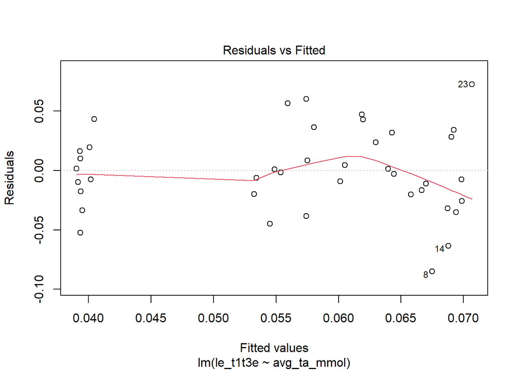

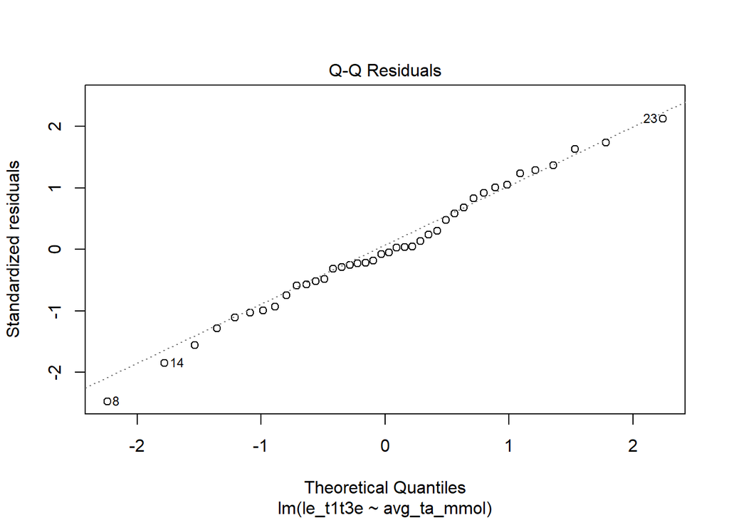

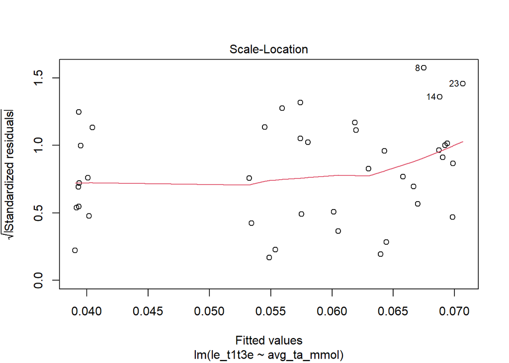

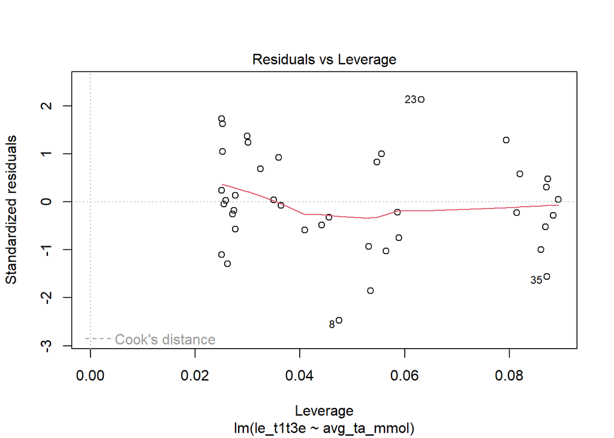

```
## avg_ta_mmol
##  0.01353356
```

```
## (Intercept)
## 0.006362687
```

```
##
## Call:
## lm(formula = le_t1t3e ~ avg_ta_mmol, data = grdata)
##
## Residuals:
##       Min        1Q    Median        3Q       Max
## -0.085147 -0.019997 -0.002287  0.024855  0.072541
##
## Coefficients:
##             Estimate Std. Error t value Pr(>|t|)
## (Intercept) 0.006363   0.025876   0.246   0.8071
## avg_ta_mmol 0.013534   0.006766   2.000   0.0527 .
## ---
## Signif. codes:  0 '***' 0.001 '**' 0.01 '*' 0.05 '.' 0.1 ' ' 1
##
## Residual standard error: 0.03523 on 38 degrees of freedom
## Multiple R-squared:  0.09525,    Adjusted R-squared:  0.07144
## F-statistic:     4 on 1 and 38 DF,  p-value: 0.05267
```

```
## [1] 0.09524794
```

```
## [1] 0.0526722
```

### 3.4.2 Plots

#### 3.4.2.1 TA_LinearExtension (T0-T3)

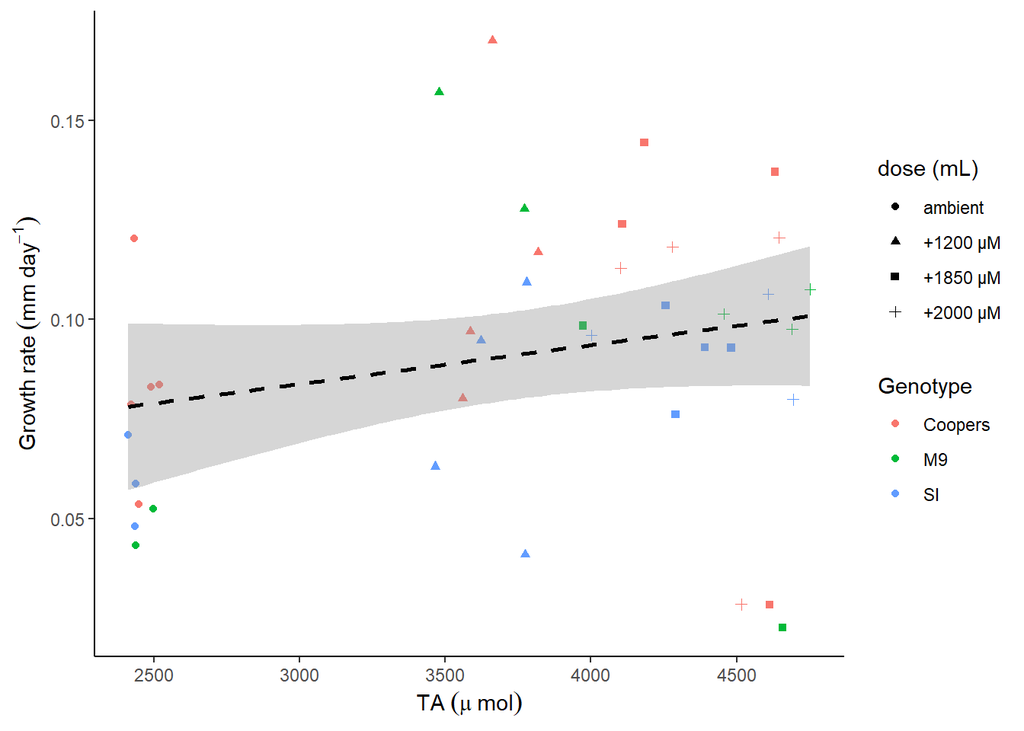

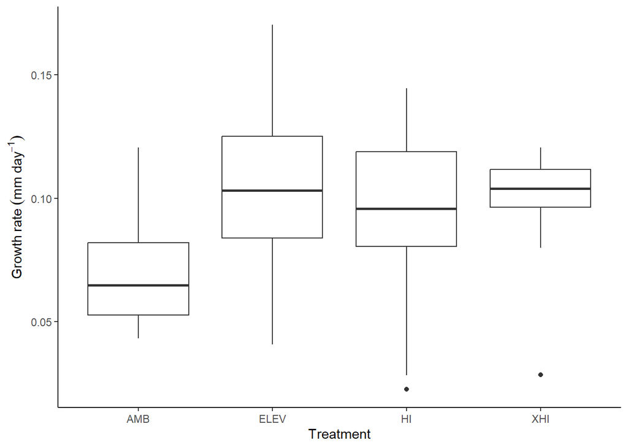

linear extension growth rates by treatment from t0 to t3